# AAL Sales Analysis Q4 2020

This project analyzes the fourth-quarter sales data for AAL across different states, demographic groups, and times of day. The objective is to identify high-performing regions and demographic segments while providing insights to assist the Sales and Marketing team in making data-driven decisions.

## Data Loading

The required libraries are imported and the dataset containing fourth-quarter apparel sales in Australia is loaded into a pandas DataFrame for analysis.

```python
import pandas as pd
from sklearn.preprocessing import MinMaxScaler
import matplotlib.pyplot as plt
import seaborn as sns

df = pd.read_csv("AusApparalSales4thQrt2020.csv")
```

## Data Wrangling

The dataset is inspected to understand its structure, identify missing values, and verify that the data is suitable for further analysis. The functions `head()`, `info()`, and `isna()` are used to explore the dataset and check for null or incorrect entries.

```python
df.head()
df.info()
df.isna().sum()
```

```
<class 'pandas.DataFrame'>
RangeIndex: 7560 entries, 0 to 7559
Data columns (total 6 columns):
 #   Column  Non-Null Count  Dtype
---  ------  --------------  -----
 0   Date    7560 non-null   str
 1   Time    7560 non-null   str
 2   State   7560 non-null   str
 3   Group   7560 non-null   str
 4   Unit    7560 non-null   int64
 5   Sales   7560 non-null   int64
dtypes: int64(2), str(4)
memory usage: 354.5 KB
```

```
Date     0
Time     0
State    0
Group    0
Unit     0
Sales    0
dtype: int64
```

## Data Cleaning

To ensure the original dataset remains unchanged during preprocessing, a copy of the dataset is created. This cleaned dataset will be used for all subsequent transformations and analysis. The dataset contained no missing values, so no rows were dropped and no imputation was required.

```python
df_clean = df.copy()

df_clean.head()
```

|  | Date | Time | State | Group | Unit | Sales |
| --- | --- | --- | --- | --- | --- | --- |
| 0 | 1-Oct-2020 | Morning | WA | Kids | 8 | 20000 |
| 1 | 1-Oct-2020 | Morning | WA | Men | 8 | 20000 |
| 2 | 1-Oct-2020 | Morning | WA | Women | 4 | 10000 |
| 3 | 1-Oct-2020 | Morning | WA | Seniors | 15 | 37500 |
| 4 | 1-Oct-2020 | Afternoon | WA | Kids | 3 | 7500 |

## Data Normalization

Normalization was applied using MinMaxScaler to scale the Unit and Sales values between 0 and 1. This ensures that large values do not dominate the analysis and allows fair comparison across states and demographic groups.

```python
scaler = MinMaxScaler()

df_clean[["Unit_Normalized", "Sales_Normalized"]] = scaler.fit_transform(df_clean[["Unit", "Sales"]])

df_clean[["Unit_Normalized", "Sales_Normalized"]].describe()
```

|  | Unit_Normalized | Sales_Normalized |
| --- | --- | --- |
| count | 7560.000000 | 7560.000000 |
| mean | 0.254054 | 0.254054 |
| std | 0.204784 | 0.204784 |
| min | 0.000000 | 0.000000 |
| 25% | 0.095238 | 0.095238 |
| 50% | 0.190476 | 0.190476 |
| 75% | 0.380952 | 0.380952 |
| max | 1.000000 | 1.000000 |

## Data Analysis

Descriptive statistical analysis is performed on the Sales and Unit columns. The metrics calculated include the mean, median, mode, and standard deviation, which provide insight into the distribution and variability of the sales data.

```python
df_clean["Sales"].mean()
df_clean["Sales"].median()
df_clean["Sales"].mode()
df_clean["Sales"].std()

df_clean["Unit"].mean()
df_clean["Unit"].median()
df_clean["Unit"].mode()
df_clean["Unit"].std()

print("Sales - Mean:", df_clean["Sales"].mean())
print("Sales - Median:", df_clean["Sales"].median())
print("Sales - Mode:", df_clean["Sales"].mode()[0])
print("Sales - Standard Deviation:", df_clean["Sales"].std())

print("Unit - Mean:", df_clean["Unit"].mean())
print("Unit - Median:", df_clean["Unit"].median())
print("Unit - Mode:", df_clean["Unit"].mode()[0])
print("Unit - Standard Deviation:", df_clean["Unit"].std())
```

```
Sales - Mean: 45013.5582010582
Sales - Median: 35000.0
Sales - Mode: 22500
Sales - Standard Deviation: 32253.506943966073
Unit - Mean: 18.00542328042328
Unit - Median: 14.0
Unit - Mode: 9
Unit - Standard Deviation: 12.90140277758643
```

## Sales Reports

Weekly, monthly, and quarterly reports are generated to summarize sales trends over time. These reports provide insights into how sales vary throughout the quarter and help identify periods of higher or lower activity. The groupby() function is appropriate for data chunking in this project because it allows sales to be aggregated by state, group, week, month, quarter, and time of day. This makes it easier to compare business performance across categories.

```python
df_clean[["Unit", "Sales"]].corr()
df_clean.groupby("State")[["Unit", "Sales"]].sum()
df_clean.groupby("Time")[["Unit", "Sales"]].sum()
df_clean.groupby("Group")[["Unit", "Sales"]].sum().sort_values(by="Sales", ascending=False)
group_sales = df_clean.groupby("Group")[["Unit", "Sales"]].sum().sort_values(by="Sales", ascending=False)
state_sales = df_clean.groupby("State")[["Unit", "Sales"]].sum().sort_values(by="Sales", ascending=False)

print("Highest Sales Group:\n", group_sales.head(1).reset_index().to_string(index=False),
      "\n\nLowest Sales Group:\n", group_sales.tail(1).reset_index().to_string(index=False),
      "\n\nSales by State:\n", state_sales,
      "\n\nHighest Sales State:\n", state_sales.head(1).reset_index().to_string(index=False),
      "\n\nLowest Sales State:\n", state_sales.tail(1).reset_index().to_string(index=False))
```

```
Highest Sales Group:
 Group  Unit    Sales
  Men 34300 85750000

Lowest Sales Group:
    Group  Unit    Sales
 Seniors 33615 84037500

Sales by State:
         Unit      Sales
State
VIC    42226  105565000
NSW    29988   74970000
SA     23543   58857500
QLD    13367   33417500
TAS     9104   22760000
NT      9032   22580000
WA      8861   22152500

Highest Sales State:
 State  Unit     Sales
  VIC 42226 105565000

Lowest Sales State:
 State  Unit    Sales
   WA  8861 22152500
```

```python
df_clean["Date"] = pd.to_datetime(df_clean["Date"],)
df_clean["Week"] = df_clean["Date"].dt.isocalendar().week
df_clean["Month"] = df_clean["Date"].dt.month
df_clean["Quarter"] = df_clean["Date"].dt.quarter
daily_sales = df_clean.groupby("Date")[["Unit", "Sales"]].sum()
weekly_sales = df_clean.groupby("Week")[["Unit", "Sales"]].sum()
monthly_sales = df_clean.groupby("Month")[["Unit", "Sales"]].sum()
quarterly_sales = df_clean.groupby("Quarter")[["Unit", "Sales"]].sum()
time_sales = df_clean.groupby("Time")[["Sales"]].sum()

print("Daily Sales:\n\n", daily_sales.reset_index().to_string(index=False),
    "\n\nWeekly Sales:\n\n", weekly_sales.reset_index().to_string(index=False),
    "\n\nMonthly Sales:\n\n", monthly_sales.reset_index().to_string(index=False),
    "\n\nQuarterly Sales:\n\n", quarterly_sales.reset_index().to_string(index=False))
```

```
Daily Sales:

       Date  Unit   Sales
2020-10-01  1488 3720000
2020-10-02  1486 3715000
2020-10-03  1556 3890000
2020-10-04  1488 3720000
2020-10-05  1545 3862500
2020-10-06  1584 3960000
2020-10-07  1485 3712500
2020-10-08  1578 3945000
2020-10-09  1458 3645000
2020-10-10  1602 4005000
2020-10-11  1549 3872500
2020-10-12  1518 3795000
2020-10-13  1541 3852500
2020-10-14  1582 3955000
2020-10-15  1512 3780000
2020-10-16  1518 3795000
2020-10-17  1524 3810000
2020-10-18  1461 3652500
2020-10-19  1584 3960000
2020-10-20  1468 3670000
2020-10-21  1564 3910000
2020-10-22  1504 3760000
2020-10-23  1465 3662500
2020-10-24  1591 3977500
2020-10-25  1550 3875000
2020-10-26  1494 3735000
2020-10-27  1487 3717500
2020-10-28  1484 3710000
2020-10-29  1529 3822500
2020-10-30  1521 3802500
2020-11-01  1208 3020000
2020-11-02  1090 2725000
2020-11-03  1151 2877500
2020-11-04  1257 3142500
2020-11-05  1230 3075000
2020-11-06  1134 2835000
2020-11-07  1200 3000000
```

[output cut: 68 more lines]

```
   51 12662 31655000
   52 12708 31770000
   53  5517 13792500

Monthly Sales:

  Month  Unit     Sales
    10 45716 114290000
    11 36273  90682500
    12 54132 135330000

Quarterly Sales:

  Quarter   Unit     Sales
       4 136121 340302500
```

## Data Visualization

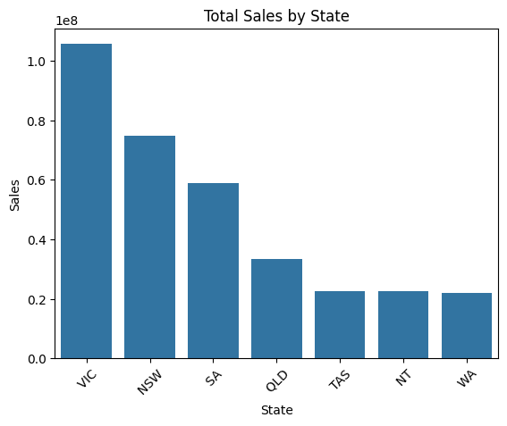

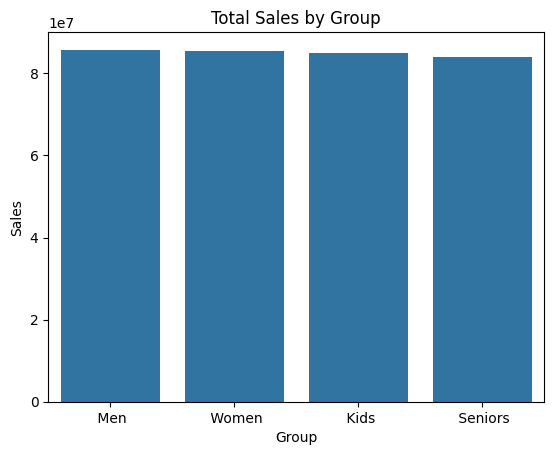

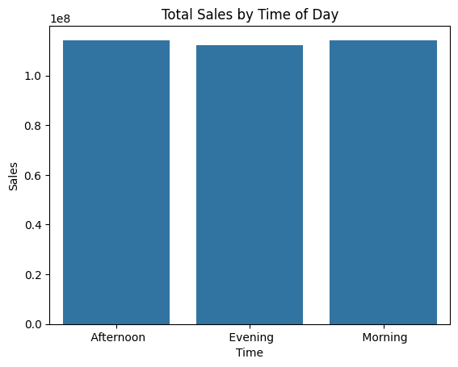

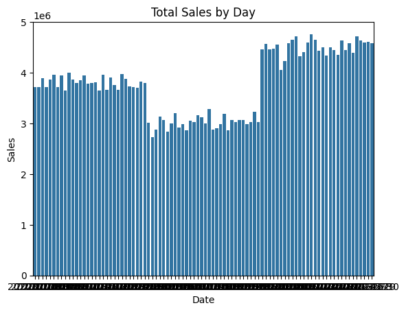

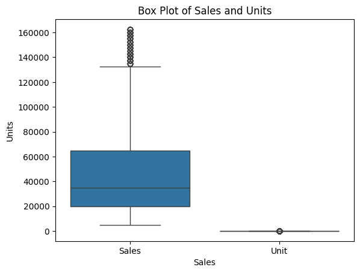

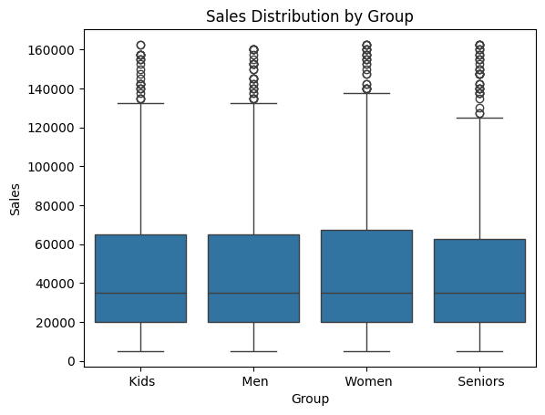

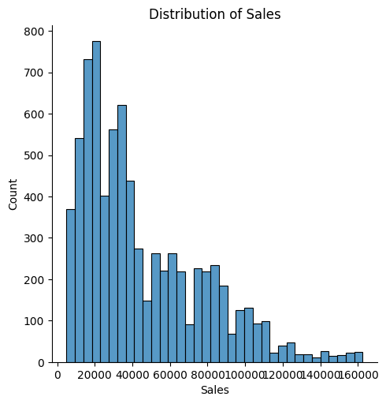

```python
plt.figure()
sns.barplot(data=state_sales.reset_index(), x="State", y="Sales")
plt.title("Total Sales by State")
plt.xlabel("State")
plt.ylabel("Sales")
plt.xticks(rotation=45)
plt.show()

plt.figure()
sns.barplot(data=group_sales.reset_index(), x="Group", y="Sales")
plt.title("Total Sales by Group")
plt.show()

plt.figure()
sns.barplot(data=time_sales.reset_index(), x="Time", y="Sales")
plt.title("Total Sales by Time of Day")
plt.show()

plt.figure()
sns.barplot(data=daily_sales.reset_index(), x="Date", y="Sales")
plt.title("Total Sales by Day")
plt.xlabel("Date")
plt.ylabel("Sales")
plt.show()

plt.figure()
sns.boxplot(data=df_clean[["Sales", "Unit"]])
plt.title("Box Plot of Sales and Units")
plt.xlabel("Sales")
plt.ylabel("Units")
plt.show()

plt.figure()
sns.boxplot(data=df_clean, x="Group", y="Sales")
plt.title("Sales Distribution by Group")
plt.show()

plt.figure()
sns.displot(df_clean["Sales"])
plt.title("Distribution of Sales")
plt.show()
```

## Insights and Recommendations

Based on the analysis conducted:

• Certain states generate significantly higher sales revenue compared to others.

### Recommendations

• Expand marketing campaigns in lower-performing states.

• Focus promotions and inventory planning on the highest-performing demographic groups.